# Analisis Segmentasi Pelanggan Berbasis RFM pada Database Sakila Menggunakan K-Means Clustering

## 12.4 Komposisi Segmen

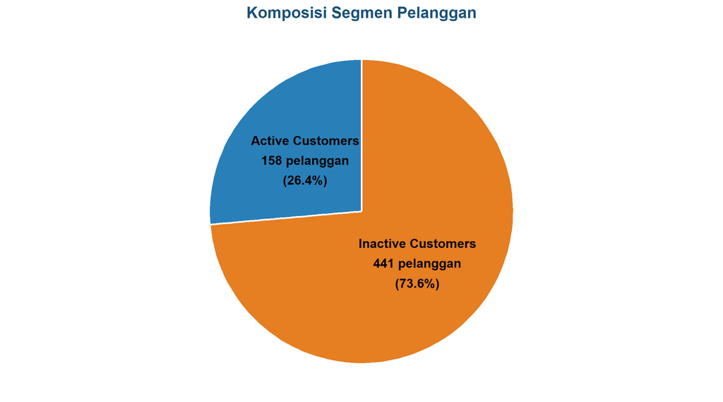

```r
komposisi <- rfm_plot %>%
  count(label) %>%
  mutate(
    pct       = n / sum(n),
    label_pie = sprintf("%s\n%d pelanggan\n(%.1f%%)", label, n, pct * 100)
  )

ggplot(komposisi, aes(x = "", y = n, fill = label)) +
  geom_col(width = 1, color = "white", linewidth = 0.8) +
  coord_polar("y", start = 0) +
  geom_text(aes(label = label_pie),
            position = position_stack(vjust = 0.5),
            size = 4, lineheight = 1.3, fontface = "bold") +
  scale_fill_manual(values = pal_cluster) +
  theme_void() +
  theme(
    legend.position = "none",
    plot.title = element_text(face = "bold", size = 14,
                              color = "#1a5276", hjust = 0.5)
  ) +
  labs(title = "Komposisi Segmen Pelanggan")
```

## 12.5 Visualisasi PCA 2D

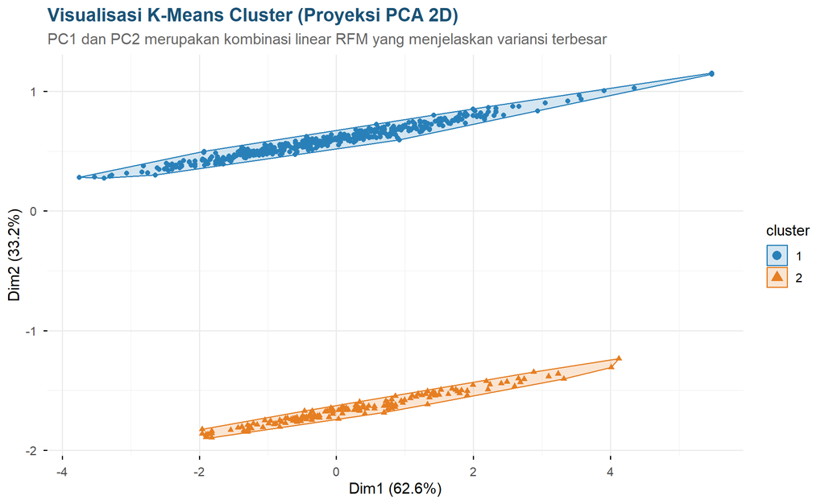

```r
fviz_cluster(km_final,
             data         = rfm_matrix,
             geom         = "point",
             ellipse.type = "convex",
             palette      = pal_cluster,
             ggtheme      = theme_minimal(base_size = 12),
             main         = "Visualisasi K-Means Cluster (Proyeksi PCA 2D)") +
  labs(subtitle = "PC1 dan PC2 merupakan kombinasi linear RFM yang menjelaskan variansi terbesar") +
  theme(plot.title    = element_text(face = "bold", color = "#1a5276"),
        plot.subtitle = element_text(color = "#666"))
```

**Catatan PCA:** Proyeksi PCA mereduksi tiga dimensi RFM menjadi dua komponen utama untuk keperluan visualisasi. Pola pemisahan kedua cluster yang terlihat pada plot ini mendukung hasil segmentasi K-Means, meskipun perlu diingat bahwa proyeksi dua dimensi tidak sepenuhnya merepresentasikan jarak dalam ruang tiga dimensi aslinya. Elips konveks pada visualisasi ini merepresentasikan batas terluar tiap cluster, bukan interval kepercayaan statistik.

# 13 Interpretasi Segmen

**Prinsip interpretasi:** Seluruh narasi di bawah ini didasarkan pada nilai rata-rata RFM aktual dari data, bukan asumsi generik. Mengingat data Sakila adalah *sample database* dengan karakteristik historis tertentu, interpretasi bisnis yang disampaikan bersifat kontekstual dan perlu disesuaikan apabila diterapkan pada data operasional nyata.

```r
# Tabel interpretasi dari cluster_profile yang sudah memiliki kolom label
interp_df <- cluster_profile %>%
  mutate(
    Karakteristik = sprintf(
      "Recency rata-rata %.1f hari | Frequency rata-rata %.1f kali | Monetary rata-rata $%.2f | Sil. avg %.3f",
      recency_avg, freq_avg, monetary_avg, sil_avg
    ),
    Strategi = dplyr::case_when(
      label == "Active Customers"   ~
        "Pertahankan keterlibatan pelanggan melalui program loyalitas berbasis frekuensi transaksi. Tawarkan rekomendasi film yang relevan berdasarkan histori genre yang paling sering disewa. Komunikasi yang dipersonalisasi dapat membantu memperpanjang siklus transaksi.",
      label == "Inactive Customers" ~
        "Pertimbangkan kampanye reaktivasi dengan insentif seperti diskon untuk rental pertama setelah kembali aktif. Lakukan survei singkat untuk memahami alasan ketidakaktifan. Evaluasi ROI kampanye sebelum eskalasi skala penuh.",
      TRUE ~ "-"
    )
  ) %>%
  select(Segmen = label, Karakteristik, Strategi)

# Warna per baris (dinamis mengikuti jumlah baris)
warna_baris <- pal_cluster[seq_len(nrow(interp_df))]

tbl <- kable(interp_df,
             caption = "Interpretasi dan Pendekatan Bisnis per Segmen") %>%
  kable_styling(bootstrap_options = c("striped", "hover", "bordered"),
                full_width = TRUE) %>%
  column_spec(2, italic = FALSE, width = "35%") %>%
  column_spec(3, italic = TRUE,  width = "40%")

for (i in seq_len(nrow(interp_df))) {
  tbl <- row_spec(tbl, i, bold = TRUE, color = "white",
                  background = warna_baris[i])
}
tbl
```

Interpretasi dan Pendekatan Bisnis per Segmen

[output not shown]

# 14 Rekomendasi Bisnis

## 14.1 Temuan Utama Berbasis Data

**1. Recency sebagai dimensi pembeda utama pada dataset ini** Segmentasi k=2 yang dihasilkan data menunjukkan bahwa dimensi yang paling membedakan kedua cluster adalah *kapan* terakhir pelanggan bertransaksi. Hal ini kemungkinan dipengaruhi oleh struktur historis database Sakila yang mencatat dua periode aktivitas berbeda. Pada data bisnis nyata, pola ini tidak selalu terulang dengan cara yang sama, sehingga interpretasi perlu dilakukan secara hati-hati.

**2. Active Customers: 158 pelanggan** Kelompok ini memiliki Recency yang rendah, menunjukkan aktivitas transaksi yang relatif baru. Rata-rata Frequency 27.6 kali dan Monetary $113.29 menggambarkan keterlibatan yang cukup konsisten. Fokus strategi untuk segmen ini adalah mempertahankan keterlibatan yang sudah ada.

**3. Inactive Customers: 441 pelanggan** Kelompok ini tidak bertransaksi dalam periode yang cukup panjang (~6 bulan). Sebelum memutuskan investasi kampanye reaktivasi, perlu dipertimbangkan apakah nilai Monetary rata-rata mereka mencukupi untuk membenarkan biaya reaktivasi dibandingkan mengakuisisi pelanggan baru.

## 14.2 Rekomendasi Operasional

| # | Segmen | Aksi Spesifik | Metrik Keberhasilan |
| --- | --- | --- | --- |
| 1 | Active | Program poin per rental dengan insentif di ambang frekuensi tertentu | Peningkatan frekuensi rata-rata 10% dalam 3 bulan |
| 2 | Active | Rekomendasi film mingguan berbasis histori genre sewa | Tingkat klik (CTR) email > 20% |
| 3 | Inactive | Diskon untuk 2–3 rental pertama setelah reaktivasi | Tingkat reaktivasi > 15% dalam 30 hari |
| 4 | Inactive | Survei singkat 3 pertanyaan: alasan berhenti, preferensi saat ini, hambatan kembali | Response rate > 10% |
| 5 | Semua | Perbarui segmentasi secara berkala (misalnya bulanan) untuk memantau perubahan profil | Proporsi Active stabil atau meningkat setiap kuartal |

# 15 Keterbatasan Analisis

1. **Karakteristik data Sakila sebagai sample database:** Pola bimodal Recency bukan merupakan refleksi perilaku pelanggan yang organik, melainkan konsekuensi dari cara pengisian database sampel yang mencatat dua periode transaksi terpisah. Hasil segmentasi pada data operasional nyata kemungkinan akan menghasilkan distribusi Recency yang lebih kontinu dan profil cluster yang berbeda.
2. **Granularitas terbatas dengan k=2:** Dua segmen mungkin belum cukup untuk menangkap keragaman perilaku pelanggan secara lebih rinci. Dari sudut pandang perencanaan kampanye, analis dapat mempertimbangkan k=3 atau k=4 sebagai opsi alternatif, dengan mempertimbangkan bahwa Silhouette score kemungkinan akan menurun.
3. **Sensitivitas K-Means terhadap outlier:** K-Means menggunakan rata-rata dalam perhitungan centroid, sehingga pelanggan dengan nilai Monetary atau Frequency yang ekstrem dapat mempengaruhi posisi centroid. Alternatif seperti K-Medoids (PAM) lebih tahan terhadap pengaruh outlier.
4. **Tidak ada faktor produk atau kontekstual:** Analisis ini murni berbasis metrik transaksi tanpa mempertimbangkan preferensi genre, rating film, lokasi pelanggan, atau pola musiman. Penambahan fitur kontekstual berpotensi menghasilkan profil segmen yang lebih informatif.
5. **Snapshot statis:** Nilai RFM dihitung pada satu titik waktu. Pendekatan RFM dengan *rolling window* yang diperbarui secara berkala akan memberikan gambaran yang lebih dinamis tentang perubahan perilaku pelanggan dari waktu ke waktu.

# 16 Kesimpulan

# 17 Saran

1. **Eksplorasi granularitas k=3:** Jalankan analisis dengan k=3 untuk mengevaluasi apakah segmen *Inactive Customers* dapat dibagi menjadi sub-kelompok yang lebih bermakna secara bisnis, misalnya berdasarkan perbedaan nilai Monetary.
2. **Integrasi fitur produk:** Tambahkan informasi seperti genre film yang paling sering disewa, jumlah kategori yang diakses, atau rata-rata lama peminjaman — untuk memperkaya profil segmen di luar dimensi transaksi.
3. **Segmentasi dinamis dengan rolling window:** Bangun proses yang menghitung ulang RFM secara berkala (misalnya bulanan) dan melacak pergerakan pelanggan antar segmen dari waktu ke waktu.
4. **Perbandingan metode clustering:** Jalankan K-Medoids (PAM) dan hierarchical clustering (Ward’s linkage) pada data yang sama, lalu bandingkan kualitas cluster dan interpretasi bisnisnya untuk mengevaluasi ketahanan hasil segmentasi.
5. **Uji kampanye pada sub-sampel:** Sebelum menerapkan strategi reaktivasi ke seluruh *Inactive Customers*, uji terlebih dahulu pada sebagian kecil (misalnya 20%) secara acak. Ukur tingkat reaktivasi dan hitung perkiraan ROI sebelum perluasan skala.

# 18 Referensi

- Hughes, A. M. (1994). *Strategic Database Marketing*. Probus Publishing Company.
- Kotler, P., & Keller, K. L. (2016). *Marketing Management* (15th ed.). Pearson Education.
- MySQL AB. (2006). *Sakila Sample Database Documentation*. https://dev.mysql.com/doc/sakila/en/
- Hartigan, J. A., & Wong, M. A. (1979). Algorithm AS 136: A K-Means Clustering Algorithm. *Applied Statistics*, 28(1), 100–108.
- Rousseeuw, P. J. (1987). Silhouettes: A graphical aid to the interpretation and validation of cluster analysis. *Journal of Computational and Applied Mathematics*, 20, 53–65.
- Kaufman, L., & Rousseeuw, P. J. (1990). *Finding Groups in Data: An Introduction to Cluster Analysis*. John Wiley & Sons.

Laporan dibuat menggunakan **R Markdown** | Program Studi Statistika – FMIPA  
Universitas Sebelas Maret | *Case Method 1 – Sistem Informasi Manajemen*